# Project 2 Plots

Group 17

May 8, 2015

# Project 2 Report

Exploratory data analysis, finding the relevant MAC addresses

## Part 1 Task 1

First, we dropped the first three lines without any information using subsetting by a boolean vector and `grepl` to remove anything following a `#`.

Next, we created the `processLine` function which will process the data and create a character matrix with 10 columns from a line of the data file. This function consisted of using regular expressions, mainly `gsub`, for parsing the data.

`gsub` takes the arguments of a regular expression, a replacement, and a string, and then replaces the original argument with the replacement argument. Sometimes, `.*` is insufficient to capture a group you want because it is too greedy. To make the regular expression “lazy” (or not “greedy”), add a question mark (`?`). To parse the data, we ignored everything before `t=` appears in the string, captured the text between `t=` and `;`, and ignored everything after the `;`. We did the same for `scanMac`, `pos`, and `degree` as well. We split `pos` into the `x`, `y`, and `z` components. This graph shows only the `x` and `y` components since `z` is zero for all observations.

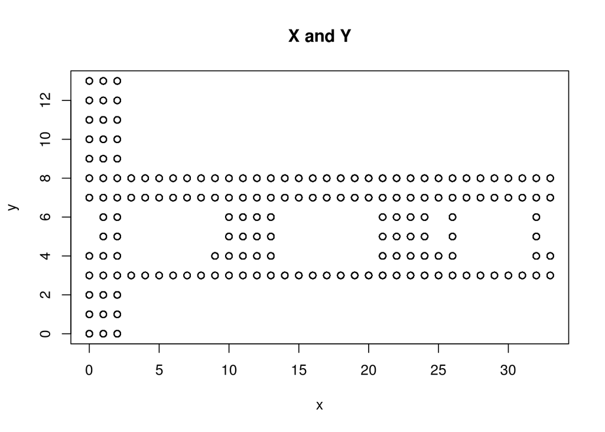

`macTestRE` is essential for determining if the extracted MAC is valid. The extracted MAC is sometimes invalid when it doesn’t exist in the data.

## Part 1 Task 2

First we deleted row names that are `NULL` and removed malformed data and ad hoc devices.

We used exploratory data analysis to figure out which devices to keep from the remaining dozen or so MAC addresses in the data. According to the data documentation, these 6 include 5 Linksys/Cisco and one Lancom L-54g routers.

First, we found the vendors by entering the prefixes into http://coffer.com/mac_find/ and kept all MACs that are from the vendors Cisco or Lancom.

First we listed out all MAC addresses and noticed that there were many ones.

```
##  [1]    418 145619  43508 145862  19162 126529 120339 132962 121325 122315
## [11]    301    103 103887      1  25112   8732      1      1   6997  50852
## [21]   7602
```

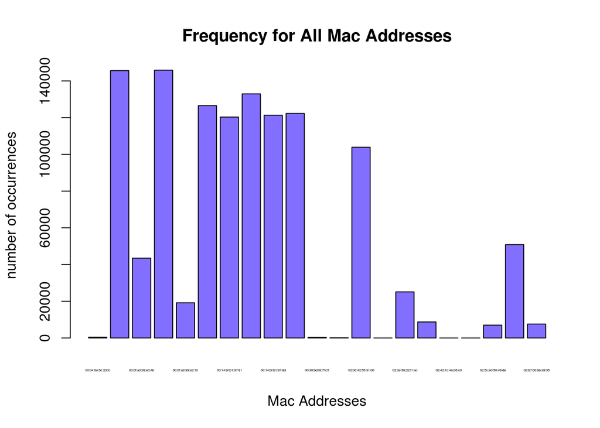

Next we removed the frequencies of ones because they are on different floors.

```
##  [1]    418 145619  43508 145862  19162 126529 120339 132962 121325 122315
## [11]    301    103 103887  25112   8732   6997  50852   7602
```

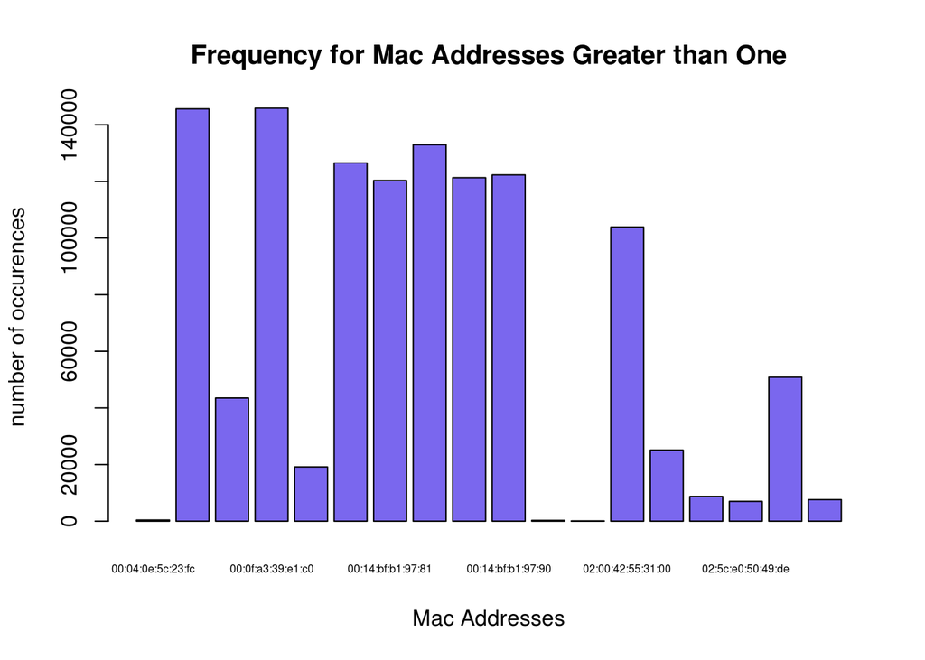

```
## [1] 145862 126529 120339 132962 121325 122315 103887
```

[figure not shown]

After choosing the routers, we converted `time`, `pos`, `orientation`, and `signal` to `numeric`. Then we dropped any irrelevant variables, i.e., variables that have the same values for all records or where the same information is captured in another variable. 1. Drop `scanMac` because `length(offline$scanMac[as.character.factor(offline$scanMac) != "00:02:2D:21:0F:33"])` returns `0`. 2. Drop `posZ` because `nrow(offline[offline$posZ != 0.0, ])` returns `0`. 3. Drop `channel` because `channel` can be determined from the MAC address. 4. Drop `type` which can be computed from `mac`. (The `mac`’s type is 3 for access point and 1 for device in adhoc mode.)

Finally we rounded the values for orientation to the nearest 45 degrees, but kept the original values too and got rid of the extraneous row names at the beginning of the data frame.

## Part 3

For part 3, we made `combineSignals` to combine the data by coordinates because each 6 have the same `(x, y)` coordinates based on how the data was cleaned. First we removed data that didn’t fit and made an index for every 6th row which we kept. Next we found the nearest neighbor by using Euclidean distance equation provided in the documentation with the groups from the combined coordinates.

Lastly, we calculated errors using the Euclidean distance again. Here we did the nearest neighbor computations and the cross validation and came up with the average errors for each `k` value.

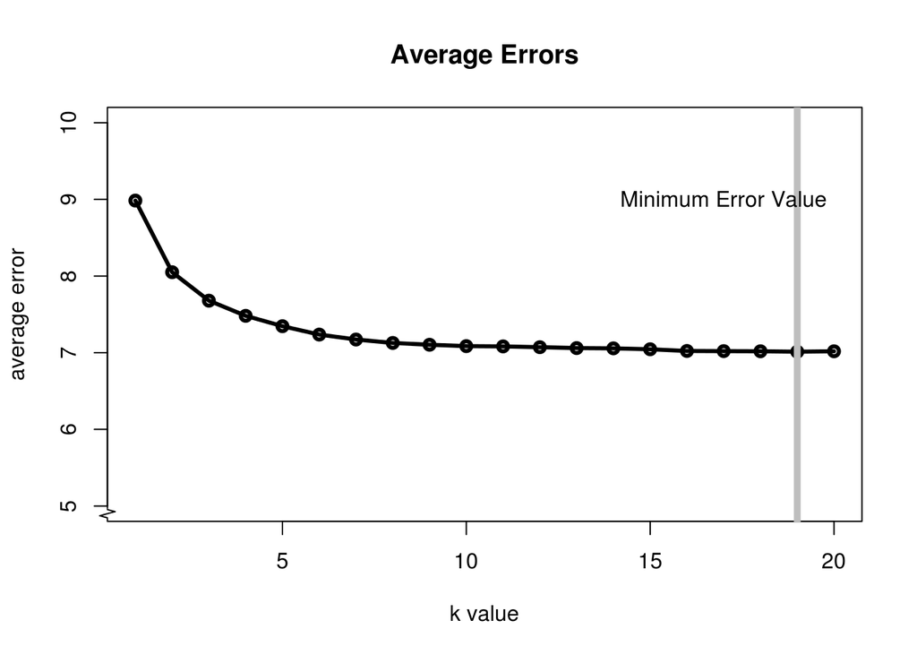

To determine the lowest `k`, we ran `which.min()` on the vector of average errors for each `k` which returned `k = 19` as the lowest error value.